# Adaptacion R 01

La manada-01

5/13/2020

# comparaciones de codigo Stata y R

- clear al == rm(list = ls())
  - elimina toda la base de datos y variables anteriormente utilizadas
- use “pathdata” == haven::read_dta(“data.dta”)
  - leen la base de datos, en `R` se automatiza en proyectos
- rename datos_viejos datos_nuevos == data_nombre <- haven::read_dta(“data.dta”)
- label var salario " = expss::apply_labels(data, col = “label”, col2 = “label2”)
  - Anades etiquetas a las variables o columnas de los datos
- generate lvar0 = ln(var0) == mutate(data, lvar0 =log(10))
  - genera nuevas variables, de ecuaciones
- egen var = mean(var0) este codigo es usado para extraer el dato del resultado como un escalar, para presentar como datos
- gen dummy = 1 if educ > 14 == mutate(data, dummy = ifelse(educ > 14, 1, 0))
  - Genera variables con condicionantes, en el ejemplo con stata creas una nueva columna llamada ‘dummy’ si la variable educ es mayor o igual a 14, pero deja vacios si no lo son, en `R` se resume asi: `dummy = ifelse(salario >= 14, 1, 0)` si la variable educ es mayor o igual a 14 imprime 1, en otros casos 0
- reg y x1 x2 == lm(y ~ x1 + x2, data = nombre de la base de datos)
  - Regresion lineal
  - En `R` puedes guardar los datos de la regresion asignando un nombre `nombre_reg <- lm(y ~ x1 + x2, data = nombre de la base de datos)
- histogram y twoway == ggplot
  - de datos a graficos

# En trabajo

## Paquetes necesarios

```r
# install.packages('tidyverse')
# install.packages('remotes')
library(tidyverse)
# install.packages('expss')
library(expss)
# remotes::iinstall_github("jacob-long/jtools")
library(jtools)
# remotes::install_github("datalorax/equatiomatic")
library(equatiomatic)
```

## Base de datos

En el dofile, de las lineas 5 - 29, sin incluir la media y la desviacion standar de las variables

```r
rm(list = ls())
salario <- haven::read_dta("Stata/salarios.dta")
# Generar variables
salario1 <- salario %>% # creamos una nueva base de datos para comparar
    # con la anterior base de datos
    mutate(lsalario = log(Salario),
           exper2 = exper^2,
           educ2 = educ^2,
           dumm = ifelse(educ >= 14, 1, 0)
           ) %>%
    apply_labels(Salario = "salarios en miles de soles para Junín",
                 educ = "años de educación",
                 exper = "años de experiencia",
                 lsalario = "logaritmo neperiano del salario",
                 educ2 = "años al cuadrado de educación",
                 exper2 = "años al cuadrado de experiencia"
    )

tibble(
    variable = c('Salarios', 'educacion'),
    media = c(mean(salario1$Salario), mean(salario1$educ)),
    sd = c(sd(salario1$Salario, sd(salario1$educ))))
```

```
## # A tibble: 2 x 3
##   variable  media    sd
##   <chr>     <dbl> <dbl>
## 1 Salarios  958.   404.
## 2 educacion  13.5  404.
```

## Despues de la linea 31

```r
r1 <- lm(lsalario ~ educ + exper, data = salario1)
#regresion
summ(r1)
```

```
## MODEL INFO:
## Observations: 935
## Dependent Variable: lsalario
## Type: OLS linear regression
##
## MODEL FIT:
## F(2,932) = 70.16, p = 0.00
## R² = 0.13
## Adj. R² = 0.13
##
## Standard errors: OLS
## -----------------------------------------------
##                     Est.   S.E.   t val.      p
## ----------------- ------ ------ -------- ------
## (Intercept)         5.50   0.11    49.12   0.00
## educ                0.08   0.01    11.83   0.00
## exper               0.02   0.00     5.99   0.00
## -----------------------------------------------
```

## Graficos RBASE

### Solo R

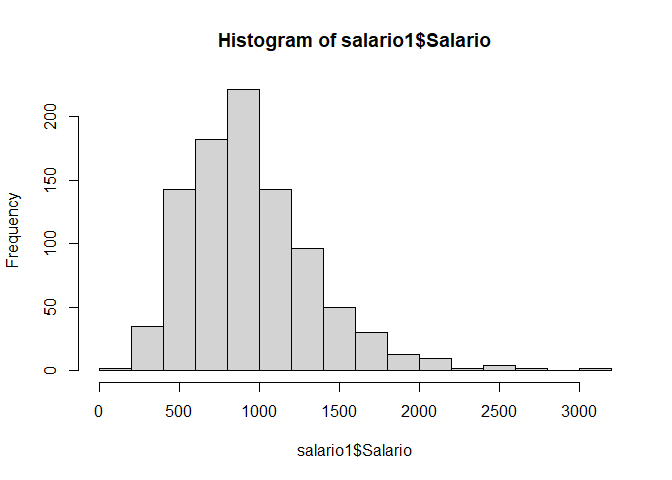

```r
hist(salario1$Salario)
```

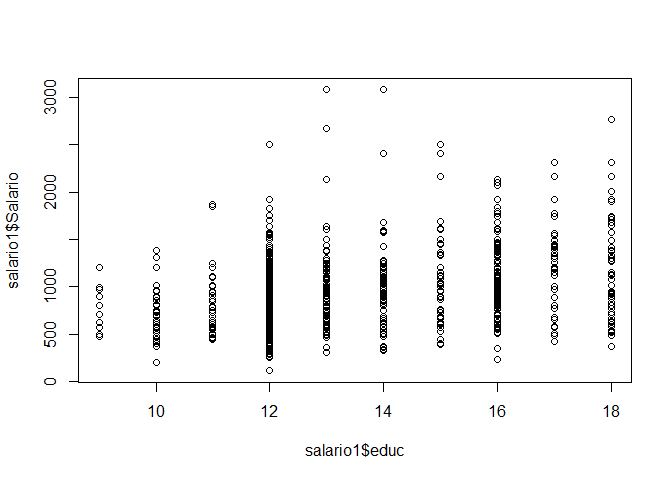

```r
plot(salario1$educ, salario1$Salario)
```

## Graficos ggplot2

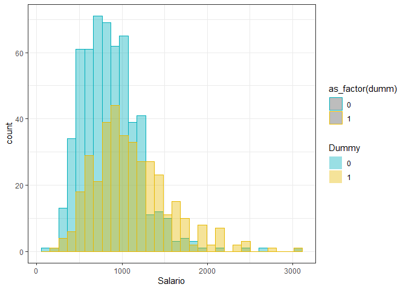

```r
salario1 %>%
    ggplot(aes(Salario)) +
    geom_histogram(
        aes(color = as_factor(dumm),
            fill = as_factor(dumm)
            ),
        alpha=0.4, position = 'identity', bin = 50
        )+
    theme_bw() +
    labs(fill="Dummy") +
    scale_fill_manual(values = c("#00AFBB", "#E7B800")) +
    scale_color_manual(values = c("#00AFBB", "#E7B800"))
```

### scatter plot

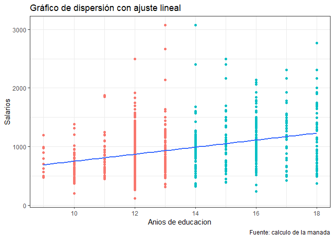

```r
salario1 %>%
    ggplot(aes(educ, Salario)) + geom_point(aes(color = as_factor(dumm))) +
    theme_bw() + geom_smooth(method = lm, se = F) +
    labs(title ="Gráfico de dispersión con ajuste lineal",
         caption = "Fuente: calculo de la manada",
         x = "Anios de educacion", y = "Salarios"
         ) +
    theme(legend.position = "none")
```

## extraccion automatica de los modelos predictivos

```r
extract_eq(r1)
```

$$\text{lsalario} = \alpha + \beta_{1}(\text{educ}) + \beta_{2}(\text{exper}) + \epsilon$$

```r
extract_eq(r1, use_coefs = TRUE)
```

$$\text{lsalario} = 5.5 + 0.08(\text{educ}) + 0.02(\text{exper}) + \epsilon$$